# 抽样大作业

人民大学-钟保罗-2019101155

2019-11-08

# 作业要求

作业要求：对贷款数据集，用 R 或 python 软件分别计算简单随机抽样、分层随机 抽中的样本质量和统计最优样本容量，并进行比较。 本次作业选择R进行简单抽样和分层随机抽样的对比。

# 数据预处理和描述统计

## 收入数据情况

首先使用R读取数据，由于收入为连续型变量，所以需要观察income数据情况，以便后期分组进行离散化处理。income的四分位数及均值如下：

```r
# 加载数据包
library(ggplot2)
library(bbplot)
#读取数据
data = read.csv('d:\\大数据相关\\抽样\\LoanStats3c\\LoanStats3c.csv')
income = na.omit(data[,'annual_inc'])
data_income=data.frame(as.matrix(summary(income)))
colnames(data_income) = 'value'
knitr::kable(data_income)
```

|  | value |
| --- | --- |
| Min. | 3000.00 |
| 1st Qu. | 45377.00 |
| Median | 65000.00 |
| Mean | 74854.15 |
| 3rd Qu. | 90000.00 |
| Max. | 7500000.00 |

对income数据进行合理分组，最终分为16个组。对每组内的样本进行计数，画出income的分布图。发现数据主要集中在40000-70000范围内。绘制年收入分组频数图如下：

```r
my_break = c(0,10000*(1:10),1500000,100000*(2:5),max(income))
income_cut = cut(income,breaks=my_break)
table(income_cut)
```

```
## income_cut
##         (0,1e+04]     (1e+04,2e+04]     (2e+04,3e+04]     (3e+04,4e+04]
##               160              3088             13402             26150
##     (4e+04,5e+04]     (5e+04,6e+04]     (6e+04,7e+04]     (7e+04,8e+04]
##             33754             33105             27676             23963
##     (8e+04,9e+04]     (9e+04,1e+05]     (1e+05,2e+05]     (2e+05,3e+05]
##             17916             14742             37280              3252
##     (3e+05,4e+05]     (4e+05,5e+05]   (5e+05,1.5e+06] (1.5e+06,7.5e+06]
##               650               261               222                 8
```

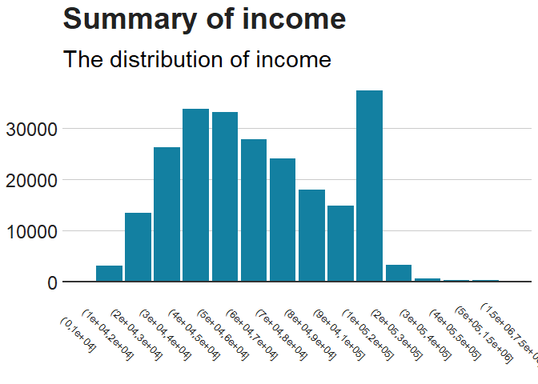

```r
freq = table(income_cut)/length(income)
mydata = data.frame(table(income_cut))
bars = ggplot(data = mydata , aes(x = income_cut,y = Freq))+
  geom_bar(stat = 'identity',position= 'identity',fill = '#1380A1')+
  geom_hline(yintercept = 0, size = 1, colour="#333333") + bbc_style()+
  labs(title="Summary of income",subtitle='The distribution of income',x='income',y='count')+
  theme(axis.text.x = element_text(size = 10,angle = 315, hjust = 0.5, vjust = 0.5))
bars
```

## 样本容量的确定

因为要观察样本质量和样本容量之间的关系，在样本量较小的时候，样本质量随着样本量的变化较大；而当样本量较大接近样本总量时，样本质量的变化较小。因此在选取样本容量时，我们通过指数函数构建如下样本数，选取68个抽样样本数。

```r
#通过指数分布选取68个样本容量
x = seq(10,20,0.1)
y = 2^(x)
sampl = round(y)[1:68]
sample_num = as.matrix(sampl)
```

## 构建随机抽样&分层抽样&计算样本质量得分的函数

构建随机抽样函数,该函数返回被抽到的income数据。

```r
#构建随机抽样的函数，该函数返回被抽到的income数据。
sample1 = function(x){
  y = sample(income,x)
  y = c(y,rep(NA,sampl[length(sampl)]-length(y)))
  return(y)
}
```

构建分层抽样的函数,该函数(sample_result_func)返回被抽到的income数据。

```r
#分层抽样
sample2 = function(i,j){# i 是68选1 j是16个分层
  x = sample_num_table[i,j]
  box1 = box[j]
  y = sample(sample_data[sample_data[,2]==box1,]$income,x)
  return(y)
}

sample_result_func = function(){
z = NULL
for (i in 1:68) { y = NULL
  for (j in 1:16) {
    y1 = sample2(i,j)
    y = c(y,y1)}
  y = c(y,rep(NA,(sampl[68]-length(y))))
  z = cbind(z,y)}
return (z)}
```

构建计算样本质量得分的函数，该函数返回抽样得分。

```r
#构建计算样本质量的函数，该函数返回抽样得分。
get_score = function(sample_result){
  income_sample = cut(na.omit(sample_result),breaks = my_break)
  freq1 = table(income_sample)/length(na.omit(sample_result))+1e-15#防止生成Inf
  score = exp(-sum((freq1-freq)*(log(freq1/freq))))
  return(score)
}
```

# 抽样比较

## 简单随机抽样

对每一个不同的样本容量进行50次随机抽样，通过取50次随机抽样得分的均值，避免单词抽样所带来的偶然性。并画出随样本量变化的样本质量得分变化，其中y轴是样本质量，x轴是样本容量，可以看出在样本量较小的时候，样本量的小幅提升可以带来样本质量相对大幅度的上升。

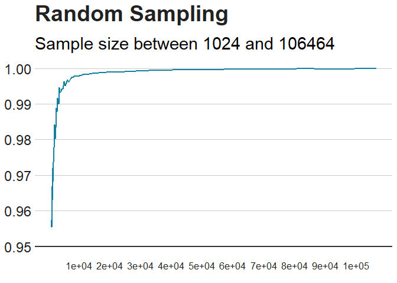

```r
scores = NULL
for ( i in 1:50) {
  sample_result = apply(sample_num,1,sample1)
  score = apply(sample_result,2,get_score)
  scores = rbind(scores,score)
}
scores_final = apply(scores,2,mean)
data_plot = data.frame(sampl,scores_final)
ggplot(data_plot,aes(x = sampl,y = scores_final))+geom_line()+bbc_style()+
  geom_line(colour = "#1380A1", size = 1) +
  geom_hline(yintercept = 0.95, size = 1, colour="#333333") +
  bbc_style() + scale_x_continuous(breaks=10000*(1:10))+
  theme(axis.text.x = element_text(size = 12)) +
  labs(title="Random Sampling",
       subtitle = "Sample size between 1024 and 106464")
```

## 分层抽样

根据总体的income频数表和样本容量，来确定每个组所需要的样本个数，在每个组内进行简单随机抽样，取50次分层抽样得分的均值，避免单次抽样带来的偶然性结果。并画出随样本量变化的样本质量得分变化。可以看出分层抽样的结果相对随机抽样来说，在小样本的表现上更加优异。

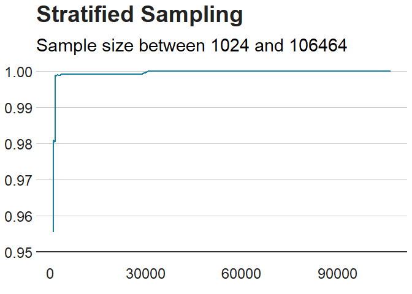

```r
#分层抽样
sample_num_table = sampl %*% t(as.vector(freq)) #计算不同层所需要的样本量
sample_data = data.frame(income,income_cut)
box = levels(income_cut)

scores = NULL
for ( i in 1:50) {
  sample_result = sample_result_func()
  score = apply(sample_result,2,get_score)
  scores = rbind(scores,score)
}
scores_final2 = apply(scores,2,mean)
data_plot2 = data.frame(sampl,scores_final2)
ggplot(data_plot2,aes(x = sampl,y = scores_final2))+geom_line()+bbc_style()+
  geom_line(colour = "#1380A1", size = 1) +
  geom_hline(yintercept = 0.95, size = 1, colour="#333333") +
  bbc_style() +
  labs(title="Stratified Sampling",
       subtitle = "Sample size between 1024 and 106464")
```

## 两个抽样方法的质量得分比较

将两个抽样方法的图重合，可以发现在小样本容量是，分层抽样明显优于随机抽样。像样本量同为2048时，随机抽样的质量为0.985，而分层抽样是0.998。但是随机抽样随着样本量的增加质量也增长的很快。 整体来看，分层抽样明显优于随机抽样,当我们选择样本质量为0.999时,分层抽样只要3104个样本，而随机抽样则需要23130个。随机抽样的成本会更高。 由此可见，分层抽样的样本更能够代表全面的总体数据。

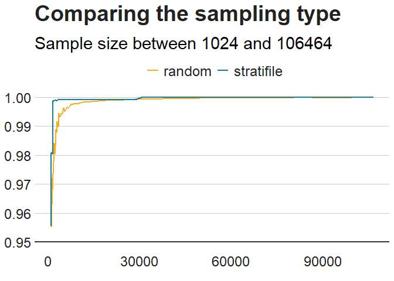

```r
data_plot_double = data.frame(rep(sampl,2),c(scores_final,scores_final2),c(rep('random',68),rep('stratifile',68)))
colnames(data_plot_double) = c('sample','scores','type')
multiple_line = ggplot(data_plot_double , aes(x = sample, y = scores, colour = type)) +
  geom_line(size = 1) +
  geom_hline(yintercept = 0.95, size = 1, colour="#333333") +
  scale_colour_manual(values = c("#FAAB18", "#1380A1")) +
  bbc_style() +
  labs(title="Comparing the sampling type",
       subtitle = "Sample size between 1024 and 106464")
multiple_line
```